# Tema 05 - La regresión logística

Estimación por máxima verosimilitud y probabilidades predichas

Autores/as

Afiliación

Pedro Albarrán

Dpto. de Fundamentos del Análisis Económico. Universidad de Alicante

Henry Redondo

Este documento acompaña a la Parte V del Tema 05. Explica con más calma cómo se estima la regresión logística, cómo se mide su ajuste y cómo se usan sus probabilidades predichas. Los ejemplos son los de la tienda: 404 clientes, de los que el 14,9 % recibió el descuento.

# 1 Una variable 0/1

Cuando la variable que queremos predecir vale 0 o 1, como `descuento`, su media condicional es una probabilidad:

$$E[\text{descuento} \mid \text{renta}] = \Pr(\text{descuento} = 1 \mid \text{renta}).$$

Una recta estimada por MCO, el **modelo lineal de probabilidad**, se lee con facilidad: con `lm(descuento ~ renta)`, cada 1.000 euros de renta restan 10 puntos de probabilidad. Pero la recta sale del intervalo $[0, 1]$, y para 35 clientes predice una probabilidad negativa. Lo que predecimos es una probabilidad, y una probabilidad está entre 0 y 1: por eso pasamos a un modelo que se quede siempre en ese intervalo.

# 2 El modelo logit

La **función logística** $\Lambda(z) = e^z / (1 + e^z)$ lleva cualquier número real al intervalo $(0, 1)$. El logit aplica esa función a un índice lineal en las variables explicativas:

$$p(x) = \Pr(\text{descuento} = 1 \mid x) = \Lambda(\beta_0 + \beta_1 x_1 + \dots + \beta_k x_k).$$

El índice es el mismo que en la regresión lineal; lo que cambia es que la probabilidad depende de él a través de una curva en forma de S. Por eso los coeficientes ya no son cambios en la probabilidad, y de ellos leemos el signo y la significatividad.

# 3 Estimar el logit: máxima verosimilitud

## 3.1 Por qué cambia el criterio

MCO elige los coeficientes que minimizan la suma de cuadrados de los residuos (SCR). Cuando el modelo es **lineal en los parámetros**, el teorema de Gauss-Markov garantiza que, con sus supuestos, MCO es el mejor estimador lineal insesgado: el más preciso entre los que aciertan en promedio. En el logit los parámetros entran dentro de $\Lambda(\cdot)$: el modelo es **no lineal en los parámetros**. Por eso se usa otro método, la **máxima verosimilitud**, que con el modelo bien especificado da estimadores consistentes (se acercan al valor poblacional al crecer la muestra) y, en muestras grandes, los más precisos. Es lo que hace `glm()`.

## 3.2 La idea de la máxima verosimilitud

Solo sabemos que hay tres tipos de moneda: equilibradas, con probabilidad de cara $p = 0{,}5$; trucadas a favor de cara, con $p = 0{,}9$, y trucadas a favor de cruz, con $p = 0{,}2$. Lanzamos una moneda cuatro veces y salen tres caras y una cruz. Con cada valor de $p$, la probabilidad de lo observado es $p \cdot p \cdot p \cdot (1 - p)$:

| $p$ | $p \cdot p \cdot p \cdot (1 - p)$ | Probabilidad de lo observado |
| --- | --- | --- |
| 0,2 | $0{,}2 \cdot 0{,}2 \cdot 0{,}2 \cdot 0{,}8$ | 0,0064 |
| 0,5 | $0{,}5 \cdot 0{,}5 \cdot 0{,}5 \cdot 0{,}5$ | 0,0625 |
| 0,9 | $0{,}9 \cdot 0{,}9 \cdot 0{,}9 \cdot 0{,}1$ | **0,0729** |

Esa probabilidad, vista como función de $p$, es la **verosimilitud**, $L(p) = p \cdot p \cdot p \cdot (1 - p)$. La **máxima verosimilitud** elige el $p$ con el que lo observado es más probable: la moneda trucada a favor de cara, $p = 0{,}9$.

En la tienda, cada cliente es una tirada, y «cara» es recibir el descuento. La diferencia es que cada cliente tiene su propia probabilidad, que depende de sus características a través del logit, $p(x_i) = \Lambda(\beta_0 + \beta_1 x_{i1} + \dots + \beta_k x_{ik})$. Un cliente con descuento aporta $p(x_i)$ y uno sin descuento, $1 - p(x_i)$, así que la verosimilitud es

$$L(\beta) = \prod_{i:\, y_i = 1} p(x_i) \prod_{i:\, y_i = 0} \bigl(1 - p(x_i)\bigr),$$

y el estimador de **máxima verosimilitud** son los $\beta$ que la hacen máxima. Si el modelo solo tiene constante, todos los clientes tienen la misma probabilidad, y la estimación es la proporción de clientes con descuento, 0,149.

En la práctica se maximiza su logaritmo, la **log-verosimilitud**:

$$\ell(\beta) = \log L(\beta) = \sum_{i=1}^{n} \Bigl[\, y_i \log p(x_i) + (1 - y_i) \log\bigl(1 - p(x_i)\bigr) \Bigr].$$

Como el logaritmo es creciente, el máximo está en los mismos $\beta$, y el logaritmo convierte multiplicar en sumar, $\log(a \cdot b) = \log a + \log b$. Eso facilita las cosas por dos razones:

- La verosimilitud tiene un factor por cliente, y la log-verosimilitud, un sumando por cliente, como la SCR. Para buscar el máximo se deriva, y la derivada de una suma es la suma de las derivadas.
- Cada factor es una probabilidad menor que 1, así que el producto encoge con cada cliente: con los 404 clientes, la verosimilitud del logit de la renta, la edad y la zona es del orden de $10^{-62}$, y con unos 2.500 clientes R la redondearía a 0 y ya no podría comparar unos $\beta$ con otros. Su logaritmo es −142,4. Es la misma propiedad que hacía útil el eje logarítmico del Tema 04: multiplicar por 10 pasaba a ser avanzar siempre la misma distancia, y valores de órdenes de magnitud muy distintos cabían en un gráfico.

El gráfico muestra $\ell$ para el logit con la renta, moviendo la pendiente y dejando la constante en su valor estimado. Es la misma búsqueda que en MCO, dada la vuelta: allí se elegía la recta con la SCR mínima y aquí la pendiente con la log-verosimilitud máxima, que es la que da `glm()`.

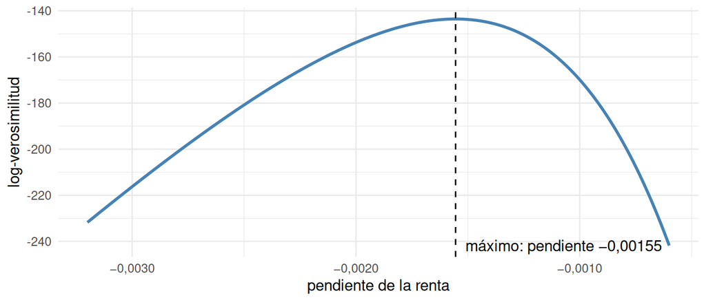

El máximo no tiene una fórmula cerrada como la de MCO: `glm()` lo busca por aproximaciones sucesivas, y `summary()` dice cuántas hizo («Number of Fisher Scoring iterations»). La máxima verosimilitud sirve para cualquier modelo que diga qué probabilidad (o densidad, si $y$ es continua) tiene cada dato; en el modelo lineal con errores normales, maximizar la verosimilitud es minimizar la SCR, así que MCO es un caso particular.

# 4 La verosimilitud como medida de ajuste

Una vez estimado el modelo, la log-verosimilitud en el máximo dice cómo de probable hace el modelo lo observado, y sirve para comparar modelos en la misma muestra: más alta (más cerca de cero), mejor ajuste. La tabla da también $-2\ell$, que enseguida veremos con el nombre de desviación.

| Modelo | Log-verosimilitud | Desviación (−2ℓ) |
| --- | --- | --- |
| Solo constante | −169,73 | 339,46 |
| Renta | −143,55 | 287,10 |
| Renta, edad y zona | −142,41 | 284,81 |

El modelo con solo la constante da a todos los clientes la misma probabilidad, la proporción de la muestra, y hace de referencia, como la media en el $R^2$. Añadir la renta sube mucho la log-verosimilitud; añadir la edad y la zona la sube muy poco. La log-verosimilitud de un modelo se obtiene con `logLik(logit)`, o como la desviación de `summary()` dividida por −2.

La salida de `summary()` de un logit da este ajuste como **desviación** (*deviance*), que es $-2\ell$: «Null deviance» para el modelo con solo la constante y «Residual deviance» para el estimado. La desviación hace en el logit el papel de la SCR: es menor cuanto mejor ajusta el modelo, y nunca sube al añadir variables. Por esa misma razón tiene el defecto que ya vimos en el $R^2$: medida en los datos de estimación, siempre premia al modelo más grande.

# 5 Predecir probabilidades

Lo que el logit predice es una probabilidad, y se calcula con `predict(..., type = "response")`. Sin `newdata`, para cada cliente de la muestra:

```r
logit <- glm(descuento ~ renta + edad + zona, data = tienda, family = "binomial")
prob <- predict(logit, type = "response")
summary(prob)
```

[output not shown]

Van de 0,00005 a 0,60, y su media es 0,149, la proporción de clientes con descuento. El modelo lineal de probabilidad con las mismas variables da a 40 clientes una probabilidad negativa.

Con `newdata`, las de clientes con las características que queramos, estén o no en la muestra.

# 6 Medir el error de un logit

En regresión, la SCR con la que se estima mide también el error, y su variante el RMSE se lee en las unidades de $y$: euros de gasto.

En el logit, la log-verosimilitud se puede leer en probabilidades: cada cliente suma el logaritmo de la probabilidad que el modelo dio a lo que le ocurrió. Si le dio 0,9, suma $\log 0{,}9 = -0{,}11$; si le dio 0,1, suma $\log 0{,}1 = -2{,}30$. Subir la log-verosimilitud es dar más probabilidad a lo que de verdad ocurrió.[^1]

Pero lo que queremos es **clasificar**: decir si un cliente pertenece a una clase o a otra (darle el descuento o no, que compre o no), y no la probabilidad de que pertenezca. La log-verosimilitud no dice a cuántos clientes se clasifica mal ni con qué tipo de error: dar el descuento a quien no lo necesita o negárselo a quien sí. Un modelo puede mejorarla dando algo más de seguridad a los clientes que ya clasificaba bien, sin cambiar ninguna decisión.

Para clasificar, cada probabilidad se compara con un **umbral**: con 0,5, la clase predicha es la más probable, y se usa otro si un tipo de error cuesta más que el otro. La **matriz de confusión** cruza las clases predichas con las observadas: con este logit y umbral 0,5, hay 7 clientes con descuento bien detectados, 53 con descuento que se le escapan, 343 sin descuento bien descartados y 1 dado por error. De ahí salen la **exactitud**, la proporción bien clasificada (0,866); la **sensibilidad**, la proporción de clientes con descuento que detecta (0,117), y la **especificidad**, la de clientes sin descuento que descarta (0,997). La **curva ROC** y el **AUC** resumen todos los umbrales a la vez. El detalle y el código, en las transparencias.

## Notas

[^1]: $e^{\ell/n}$ es la media geométrica de esas probabilidades. La log-verosimilitud además castiga sin límite un error cometido con mucha seguridad: si el modelo da probabilidad casi cero a un cliente que sí recibió el descuento, $\log p$ tiende a menos infinito.